# Testing Equivalence between NIRS Breakpoints and Ventilatory Thresholds

Computational Notebook

Author

Affiliation

Philip Skotzke

Department of Movement, Human and Health Sciences, University of Rome “Foro Italico”, Rome, Italy

Published

June 4, 2026

```r
# Set up for the computational notebook
# -> load packages
# -> set the base ggplot2 theme
# -> define custom colors
# -> load extra fonts
# -> save package version with {renv}

library(dplyr)      # efficient data manipulation
library(extrafont)  # fonts for publication plots
library(extrafontdb)# database for extra fonts
library(ggdist)     # plot distributions
library(ggplot2)    # create plots
library(ggtext)     # more flexible plot texts
library(grid)       # advanced figure formatting
library(gt)         # gt tables
library(gtsummary)  # summary tables
library(kableExtra) # create html tables
library(MetBrewer)  # better color palettes
library(patchwork)  # combine plots
library(readxl)     # read MS Excel files
library(renv)       # save the project environment
library(SimplyAgree)# reliability analysis & Bland-Altman plots
library(stringr)    # manipulate character strings
library(tidyr)      # data management
library(TOSTER)     # perform two onesided tests


#### set up the base theme ####
theme_set(
    theme_bw(base_size = 14) %+replace%
        theme(
            plot.title = ggtext::element_markdown(
                colour = "grey10", size = rel(1.2), hjust = 0,
                lineheight = 1.2, margin = margin(b = 7)),
            plot.title.position = "plot",
            plot.caption.position = "plot",
            panel.border = element_rect(colour = "black",
                                        fill = NA, linewidth = 0.7),
            axis.line = element_blank(),
            panel.grid.major = element_blank(),
            panel.grid.minor = element_blank(),
            text = element_text(colour = "grey20"),
            axis.text = element_text(colour = "grey20"),
            axis.title.x = element_text(margin = margin(t = 7)),
            axis.title.y.right = element_text(angle = -90,
                                              margin = margin(l = 4)),
            axis.title = element_text(face = "bold"),
            legend.margin = margin(c(1, 1, 1, 1)),
            legend.position = "top",
            legend.justification = "right",
            legend.direction = "horizontal",
            legend.key = element_blank(),
            legend.key.width = unit(0.7, 'cm'),
            legend.spacing.y = unit(0.2, 'cm'),
            strip.background = element_rect(fill = "grey95",
                                            colour = "grey10",
                                              linewidth = 0.7),
            strip.text = element_text(
                size = rel(1), margin = margin(4, 4, 4, 4)),
            complete = FALSE
        ))


#### define custom colors ####
clrs <- met.brewer("Juarez")


#### load extra fonts ####
# run only if fonts haven't been imported before

# font_import(prompt = T)

# load fonts
loadfonts(quiet = T)

#### create reproducible envvironments with {renv} ####
# run only once, then comment out

# init()

# update renv files (comment out when not needed)

# renv::snapshot()
```

## Preface

This file is the **computational notebook** accompanying the main manuscript and is stored on [Github](https://github.com/PhilipSkotzke/breakpoints_equivalence) and accessible on [OSF](https://osf.io/u8k2e/). It contains the reasoning behind analyses performed, the full details on statistical procedures and the analytic code. Please note, that:

- Sub-headers in Section 5 refer to figures and tables generated for the main manuscript or supplements. They are stored in their respective folders `/output/results` and `/output/supplementary` and not presented here.
- The code used to produce the results in this document can be viewed by clicking on the `Code` button to unfold it.

**This is a reproducible document**

This `.html` file is technically reproducible. Download the repository from OSF or GitHub and run the file `analysis_breakpoints_equivalence.qmd`.

## Hypothesis

To be transparent about our reasoning process, we make the distinction between the *research question*, the *research hypothesis*, the *empirical hypothesis* and the *statistical hypothesis* (for details read [here](https://publish.obsidian.md/methodology-swi-uds/Practise/Analyzing+research+methodology/1.+Find+the+research+question)) and state each separately.

**Note**

This is an exploratory analysis (Ditroilo et al., 2025). We use existing data to test a hypothesis, but no adequate error control can be ensured. Instead, we use our results to estimate the required sample size to reach sufficient statistical power when comparing NIRS breakpoints with ventilatory thresholds. We believe that this will help to inform future research to recruit adequate sample sizes for confirmatory studies comparing NIRS breakpoints with a criterion method.

### Research Question

Can we use NIRS-measured muscle oxygen saturation (SmO<sub>2</sub>) to delimit the three exercise intensity domains in a field based running test?

### Research Hypothesis

1. BP1 can be used interchangeably with GET.
2. BP2 can be used interchangeably with RCP.

Note, based on the existing literature no directional difference would be assumed (e.g. it is as likely that BP2 is at a higher intensity than RCP than the other way around).

### Empirical Hypothesis

1. The heart rate and speed derived from a the VAM-EVAL incremental test in highly trained male triathletes are equivalent between BP1 and GET .
2. The heart rate and speed derived from a the VAM-EVAL incremental test in highly trained male triathletes are equivalent between BP2 and RCP.

### Statistical Hypothesis

#### BP1 vs GET

$\text{H}_0: \left|\mu_{\text{GET.HR}} - \mu_{\text{BP1.HR}} \right| \geq \Delta_{\text{HR}} ~ \land ~ \left|\mu_{\text{GET.SPEED}} - \mu_{\text{BP1.SPEED}} \right| \geq \Delta_{\text{SPEED}}$

$\text{H}_1: \left|\mu_{\text{GET.HR}} - \mu_{\text{BP1.HR}} \right| < \Delta_{\text{HR}} ~ \land ~ \left|\mu_{\text{GET.SPEED}} - \mu_{\text{BP1.SPEED}} \right| < \Delta_{\text{SPEED}}$

#### BP2 vs RCP

$\text{H}_0: \left|\mu_{\text{RCP.HR}} - \mu_{\text{BP2.HR}} \right| \geq \Delta_{\text{HR}} ~ \land ~ \left|\mu_{\text{RCP.SPEED}} - \mu_{\text{BP2.SPEED}} \right| \geq \Delta_{\text{SPEED}}$

$\text{H}_1: \left|\mu_{\text{RCP.HR}} - \mu_{\text{BP2.HR}} \right| < \Delta_{\text{HR}} ~ \land ~ \left|\mu_{\text{RCP.SPEED}} - \mu_{\text{BP2.SPEED}} \right| < \Delta_{\text{SPEED}}$

Where $\Delta$ denotes the equivalence range.

As indicated by the formulation, the hypothesis can be tested using an equivalence test (Lakens, 2017). Based on the existing literature and practical relevance, the following values will be used as smallest effect size of interest (SESOI):

The test-retest reliability for speed at the GET and RCP is typically in the range of 0.2-0.4 km/h (e.g. Cerezuela-Espejo et al., 2018; Dickhuth et al., 1999). Furthermore, a critical difference of 0.5 km/h between lactate thresholds and MLSS has been used before for criterion validity and is justified by its relevance to athletic performance (Dörr, 2010). **Thus, we will use 0.5 km/h as SESOI.**

For heart rate, the typical error of measurement has been reported to be 3.8% for VT1 and 2.5% for VT2 (Weston & Gabbett, 2001), corresponding to 5 and 4 bpm, respectively. In a different investigation, the standard error of measurement was 3-4 bpm (Yogev et al., 2023). **Thus, we will use 5 bpm as SESOI.**

Please note, the two hypotheses pairs are formulated as conjunction. In contrast to Mesquida et al. (n.d.) we use logical connectors instead of set operators. We argue that the intersection-union approach is the right one for our research question. It would be justified to go a step further and use the $\land$ (“and”) connector to combine our hypotheses about the first and second threshold because only if we can use SmO<sub>2</sub> to delineate *all* three intensity domains it would be interchangeable with ventilatory thresholds. However, if NIRS can be used to establish either threshold, it would be practically useful. As a consequence, we don’t have to apply $\alpha$ error corrections.

For all analysis we use $\alpha$ < 0.05 for Type I error control as it is common practice in our field.

## Data Analysis

The data used for this analysis was generated as part of a different project, where the VAM-EVAL was performed as initial test to assess participant fitness. See the codebook (`data/input data/metadata`) for more details.

### Data Preparation

The data has been been pre-processed and only needs to be loaded.

```r
# load the data
Study_data <- read_xlsx("data/input data/data_NIRS_BPs_2025.xlsx")
```

### Descriptive Statistics

#### Descriptive Table

First, we create tables with descriptive statistics.

```r
# the gtsummary::tbl_summary() function is used after selecting the variables for participant characteristics
Study_data %>%
  select(Age, Height, Weight, ATT_left, ATT_right, Test_duration, v_peak, MAS, absVO2max, VO2max) %>%
  mutate(BMI = Weight / (Height/100)^2,
         Test_duration = Test_duration/60) %>%
    tbl_summary(
    type = ~ "continuous",
    statistic = all_continuous() ~ "{mean} \u00B1 {sd} [{min} - {max}]",
    missing_text = "missing",
    digits = list(
      c(Age, Height, Weight, ATT_left, ATT_right, Test_duration, v_peak, MAS, VO2max, BMI) ~ 1,
      c(absVO2max) ~ 0
    )
  ) %>%
  as_gt() %>%
  tab_header(title = "Participant Characteristics")
```

Participant Characteristics

| **Characteristic** | **N = 12**<sup>1</sup> |
| --- | --- |
| Age | 23.8 ± 5.1 [19.0 - 32.0] |
| Height | 175.9 ± 8.5 [167.0 - 196.0] |
| Weight | 67.4 ± 6.4 [56.0 - 78.0] |
| ATT_left | 3.8 ± 1.4 [1.6 - 7.0] |
| ATT_right | 3.6 ± 1.5 [1.5 - 7.0] |
| Test_duration | 23.3 ± 1.7 [21.0 - 26.0] |
| v_peak | 18.8 ± 0.8 [17.5 - 20.0] |
| MAS | 17.8 ± 1.0 [16.0 - 19.5] |
| absVO2max | 4,172 ± 631 [3,106 - 4,890] |
| VO2max | 62.1 ± 9.3 [47.8 - 75.0] |
| BMI | 21.8 ± 1.3 [19.4 - 23.4] |

<sup>1</sup> Mean ± SD [Min - Max]

```r
# then the variables relating to the threshold identification are selected and summarized
Study_data %>%
  select(-c(ID, Age, Height, Weight, ATT_left, ATT_right, v_peak, MAS, VO2max, absVO2max)) %>%
  tbl_summary(
    type = ~ "continuous",
    statistic = all_continuous() ~ "{mean} \u00B1 {sd}",
    missing_text = "not identified",
    digits = list(
      c(GET_speed, RCP_speed, BP1_speed, BP2_speed) ~ 1,
      c(GET_time, GET_HR, RCP_time,
        RCP_speed, BP1_time, BP1_speed, BP2_time, BP2_speed) ~ 0
    )
  ) %>%
  as_gt() %>%
  tab_header(title = "Threshold Identification Details")
```

Threshold Identification Details

| **Characteristic** | **N = 12**<sup>1</sup> |
| --- | --- |
| Test_duration | 1,398 ± 101 |
| GET_time | 765 ± 122 |
| GET_speed | 13.5 ± 1.1 |
| GET_HR | 155 ± 14 |
| RCP_time | 1,085 ± 133 |
| RCP_speed | 16 ± 1 |
| RCP_HR | 175 ± 14 |
| BP1_time | 920 ± 171 |
| BP1_speed | 15 ± 1 |
| BP1_HR | 165 ± 19 |
| BP2_time | 1,323 ± 82 |
| not identified | 2 |
| BP2_speed | 18 ± 1 |
| not identified | 2 |
| BP2_HR | 188 ± 12 |
| not identified | 2 |

<sup>1</sup> Mean ± SD

#### Visualization of Threshold estimates

To get a visual idea how the distributions of BP1/GET and BP2/RCP look like in our sample, boxplots are created.

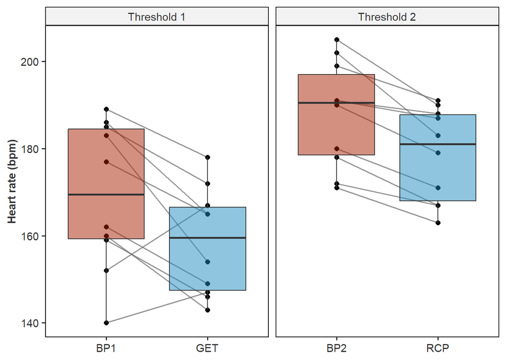

```r
bxplt_data <- Study_data |>
  pivot_longer(
    cols = matches("_(HR|Speed)$"),
    names_to = c("Measure",".value"),
    names_pattern = "(.*)_(HR|speed)"
  ) |>
  mutate(
    Method = ifelse(Measure %in% c("BP1", "BP2"), "NIRS", "VT"),
    Threshold = ifelse(Measure %in% c("BP1", "GET"), "Threshold 1", "Threshold 2"),
    Measure = factor(Measure, levels = c("BP1", "GET", "BP2", "RCP"))
 ) |>
  select(ID, speed, HR, Measure, Threshold, Method) |>
  drop_na() |>
  group_by(ID, Threshold) |>
  filter(n_distinct(Measure) == 2) |>
  group_by(ID) |>
  filter(n_distinct(Threshold) == 2) |>
  ungroup()

bxplt_data |>
  ggplot(aes(Measure, HR, group = Measure, fill = Method)) +
  geom_line(aes(group = ID), color = "grey40", alpha = 0.7, linewidth = 0.6) +
  geom_point(aes(group = ID), size = 2) +
  geom_boxplot(alpha = .5) +
  facet_wrap(~Threshold,
             scales = "free_x") +
  scale_fill_manual(values = c(clrs[1:2])) +
  labs(
    x = NULL,
    y = "Heart rate (bpm)"
  ) +
  theme(
    legend.position = "none"
  )
```

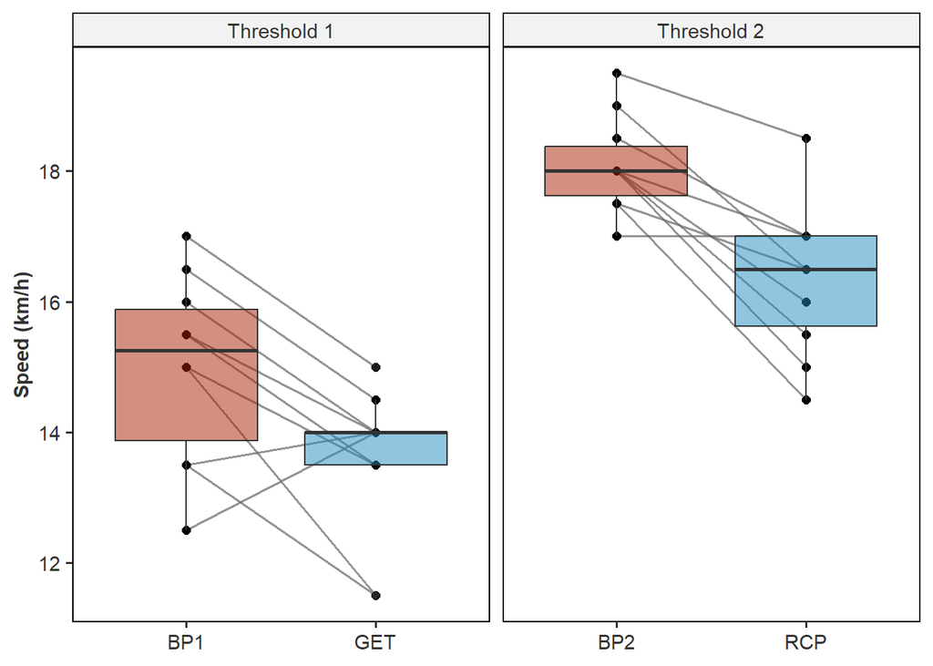

```r
bxplt_data |>
  ggplot(aes(Measure, speed, group = Measure, fill = Method)) +
  geom_line(aes(group = ID), color = "grey40", alpha = 0.7, linewidth = 0.6) +
  geom_point(aes(group = ID), size = 2) +
  geom_boxplot(alpha = .5) +
  facet_wrap(~Threshold,
             scales = "free_x") +
  scale_fill_manual(values = c(clrs[1:2])) +
  labs(
    x = NULL,
    y = "Speed (km/h)"
  ) +
  theme(
    legend.position = "none"
  )
```

#### Bland Altman Plots for Heteroscedasticity

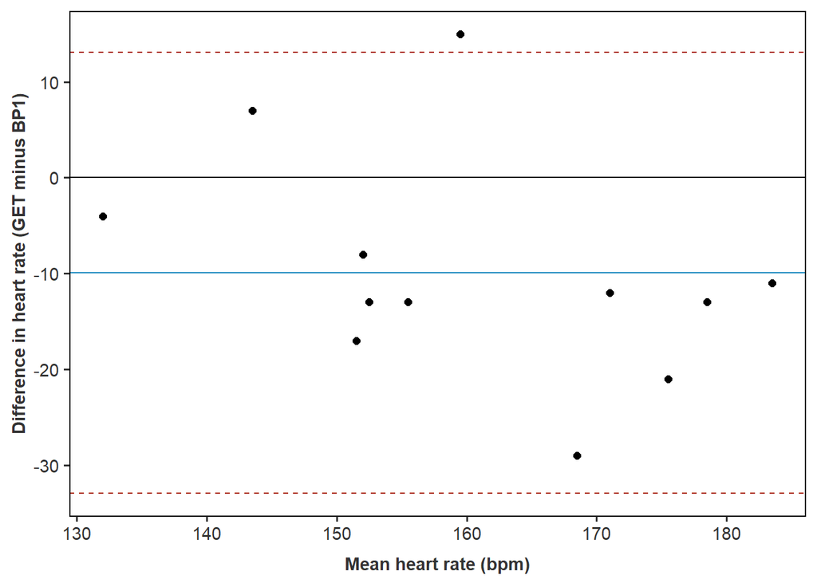

```r
# first, calculate Bland Altman statistics
BA_VT1_HR <- agreement_limit(x = "GET_HR", y ="BP1_HR", data = Study_data, loa_calc = "blandaltman")
BA_VT1_speed <- agreement_limit(x = "GET_speed", y ="BP1_speed", data = Study_data, loa_calc = "blandaltman")
BA_VT2_HR <- agreement_limit(x = "RCP_HR", y ="BP2_HR", data = Study_data, loa_calc = "blandaltman")
BA_VT2_speed <- agreement_limit(x = "RCP_speed", y ="BP2_speed", data = Study_data, loa_calc = "blandaltman")

# now create bland altman plots
# for BP1 vs GET hr
ba_Thd1_HR <- Study_data %>%
  ggplot(aes((BP1_HR + GET_HR)/2, GET_HR - BP1_HR)) +
  labs(
    x = "Mean heart rate (bpm)",
    y = "Difference in heart rate (GET minus BP1)"
  ) +
  geom_point(size = 2)

ba_Thd1_HR +
  geom_hline(yintercept = 0, linetype = "solid") +
  geom_hline(yintercept = BA_VT1_HR$loa$bias, linetype = "solid", color = clrs[2]) +
  geom_hline(yintercept = c(BA_VT1_HR$loa$lower_loa, BA_VT1_HR$loa$upper_loa), linetype = "dashed", color = clrs[1])
```

[figure not shown]

```r
# for BP1 vs GET speed
ba_Thd1_speed <- Study_data %>%
  ggplot(aes((BP1_speed + GET_speed)/2, GET_speed - BP1_speed)) +
  geom_point(size = 2) +
  labs(
    x = "Mean speed (km/h)",
    y = "Difference in speed (RCP minus BP2)"
  )

# draw fiugre and add bias + LoA
ba_Thd1_speed +
  geom_hline(yintercept = 0, linetype = "solid") +
  geom_hline(yintercept = BA_VT1_speed$loa$bias, linetype = "solid", color = clrs[2]) +
  geom_hline(yintercept = c(BA_VT1_speed$loa$lower_loa, BA_VT1_speed$loa$upper_loa), linetype = "dashed", color = clrs[1])
```

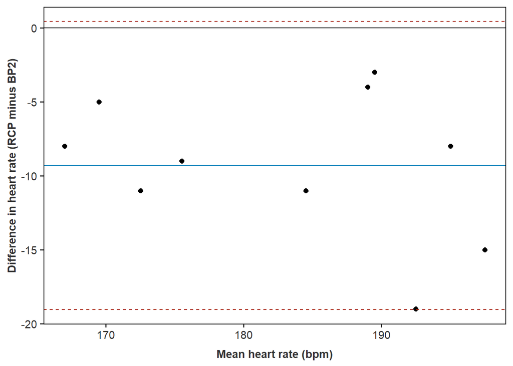

```r
# for BP2 vs RCP hr
ba_Thd2_HR <- Study_data %>%
  ggplot(aes((BP2_HR + RCP_HR)/2, RCP_HR - BP2_HR)) +
  geom_point(size = 2) +
  labs(
    x = "Mean heart rate (bpm)",
    y = "Difference in heart rate (RCP minus BP2)"
  )
ba_Thd2_HR +
  geom_hline(yintercept = 0, linetype = "solid") +
  geom_hline(yintercept = BA_VT2_HR$loa$bias, linetype = "solid", color = clrs[2]) +
  geom_hline(yintercept = c(BA_VT2_HR$loa$lower_loa, BA_VT2_HR$loa$upper_loa), linetype = "dashed", color = clrs[1])
```

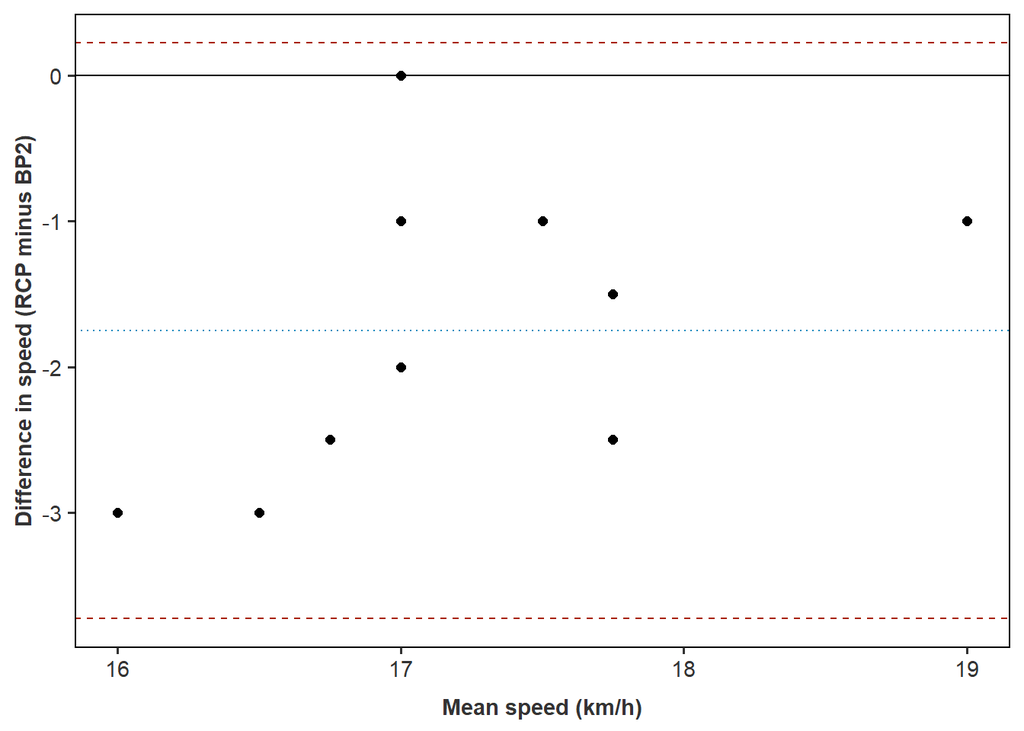

```r
# for BP2 vs RCP speed
ba_Thd2_speed <- Study_data %>%
  ggplot(aes((BP2_speed + RCP_speed)/2, RCP_speed - BP2_speed)) +
  geom_point(size = 2) +
  labs(
    x = "Mean speed (km/h)",
    y = "Difference in speed (RCP minus BP2)"
  )

ba_Thd2_speed +
  geom_hline(yintercept = 0, linetype = "solid") +
  geom_hline(yintercept = BA_VT2_speed$loa$bias, linetype = "dotted", color = clrs[2]) +
  geom_hline(yintercept = c(BA_VT2_speed$loa$lower_loa, BA_VT2_speed$loa$upper_loa), linetype = "dashed", color = clrs[1])
```

The Bland Altman plots show no clear indication of heteroscedasticity.

### Inferential Statistics

#### Reliability

The ICC(3,1) for absolute agreement is calculated to observe the relation between unexplained and explained variance. However, the `{simplyAgree}` package doesn’t natively output ICC(3,1)<sub>abs</sub>. Instead, use the output for ICC(2,1), which is numerically identical.

```r
# for that, create long-form data
Study_data_long <- Study_data %>%
  pivot_longer(
    cols = matches("_(HR|Speed)$"),
    names_to = c("Measure",".value"),
    names_pattern = "(.*)_(HR|speed)"
  ) |>
  mutate(
    Method = ifelse(Measure %in% c("BP1", "BP2"), "NIRS", "VT"),
    Threshold = ifelse(Measure %in% c("BP1", "GET"), "Threshold 1", "Threshold 2"),
    Measure = factor(Measure, levels = c("BP1", "GET", "BP2", "RCP"))
 )

# ICC for Thd1 HR
icc_Thd1_HR <- reli_aov(
  measure = "HR",
  item = "Measure",
  id = "ID",
  data = Study_data_long |> filter(Threshold == "Threshold 1")
)

# ICC for Thd1 speed
icc_Thd1_speed <- reli_aov(
  measure = "speed",
  item = "Measure",
  id = "ID",
  data = Study_data_long |> filter(Threshold == "Threshold 1")
)

# ICC for Thd2 HR
icc_Thd2_HR <- reli_aov(
  measure = "HR",
  item = "Measure",
  id = "ID",
  data = Study_data_long |> filter(Threshold == "Threshold 2")
)

# ICC for Thd2 speed
icc_Thd2_speed <- reli_aov(
  measure = "speed",
  item = "Measure",
  id = "ID",
  data = Study_data_long |> filter(Threshold == "Threshold 2")
)

# visualize
icc_results <- bind_rows(
  icc_Thd1_HR$icc[2,4:6]   |> mutate(Method = "Threshold 1 - HR",   .before = 1),
  icc_Thd1_speed$icc[2,4:6]   |> mutate(Method = "Threshold 1 - Speed",   .before = 1),
  icc_Thd2_HR$icc[2,4:6]   |> mutate(Method = "Threshold 2 - HR",   .before = 1),
  icc_Thd2_speed$icc[2,4:6]   |> mutate(Method = "Threshold 2 - Speed",   .before = 1)
)

rownames(icc_results) <- NULL  # clean up the leftover row number "2"

kbl(icc_results, digits = 3) %>%
  kable_styling(full_width = FALSE)
```

| Method | icc | lower.ci | upper.ci |
| --- | --- | --- | --- |
| Threshold 1 - HR | 0.642 | 0.163 | 0.862 |
| Threshold 1 - Speed | 0.268 | -0.091 | 0.618 |
| Threshold 2 - HR | 0.687 | -0.033 | 0.910 |
| Threshold 2 - Speed | 0.179 | -0.080 | 0.533 |

#### Equivalence Testing

To test the assumptions, the normality of differences is visually checked using qq-plots and statistically tested with the Shapiro-Wilk test for heart rate and speed at the first and second threshold.

#### First Threshold (GET vs. BP1)

##### Assumptions - heart rate

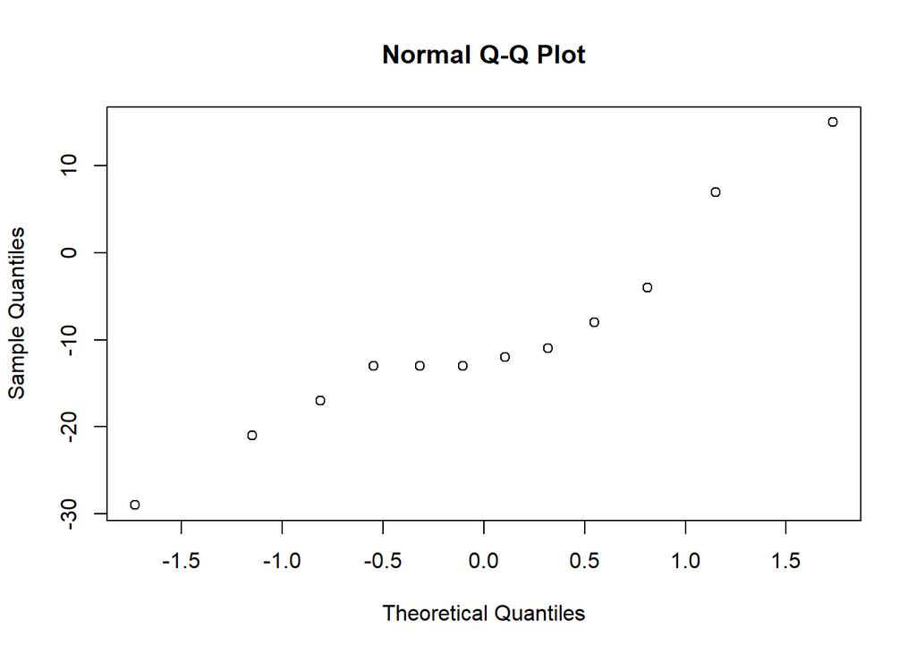

```r
# calculate the difference
diff_HR1 <- Study_data$GET_HR - Study_data$BP1_HR

# generate the qq plot
qqnorm(diff_HR1)
```

```r
# perform the Shapiro-Wilk test
shapiro.test(diff_HR1)
```

```
    Shapiro-Wilk normality test

data:  diff_HR1
W = 0.92496, p-value = 0.3297
```

The assumption of normality of the differences is not violated for heart rate.

##### TOST heart rate first threshold

```r
# the t_TOST function is used
EQ1_HR <- t_TOST(
  x = Study_data$GET_HR,
  y = Study_data$BP1_HR,
  hypothesis = "EQU",
  paired = T,
  #var.equal = T,
  eqb = 5,
  alpha = 0.05
)

# print the results
EQ1_HR
```

```
Paired t-test

The equivalence test was non-significant, t(11) = -1.5, p = 0.91
The null hypothesis test was significant, t(11) = -2.93, p = 0.01
NHST: reject null significance hypothesis that the effect is equal to zero
TOST: don't reject null equivalence hypothesis

TOST Results
                t df p.value
t-test     -2.925 11   0.014
TOST Lower -1.450 11   0.913
TOST Upper -4.400 11 < 0.001

Effect Sizes
              Estimate     SE                C.I. Conf. Level
Raw            -9.9167 3.3900 [-16.0046, -3.8287]         0.9
Hedges's g(z)  -0.7853 0.3415   [-1.2893, -0.252]         0.9
Note: SMD confidence intervals are an approximation. See vignette("SMD_calcs").
```

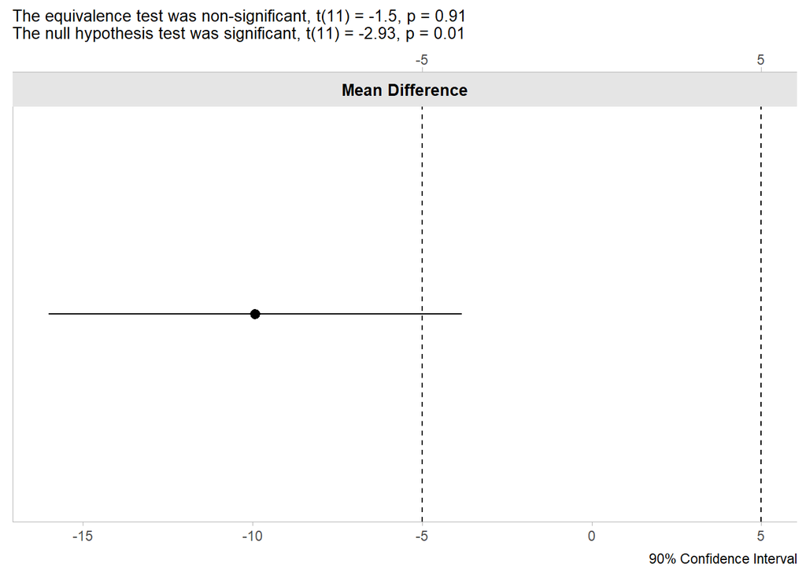

```r
plot(EQ1_HR, "simple", estimates = "raw")
```

##### Assumptions speed

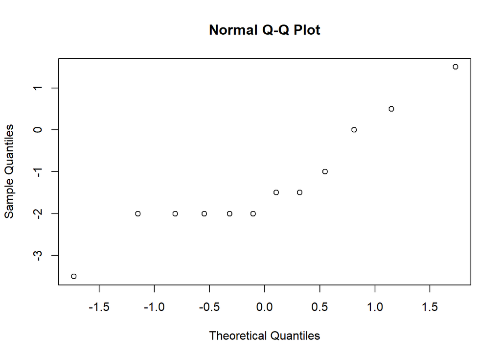

```r
# calculate the difference
diff_SP1 <- Study_data$GET_speed - Study_data$BP1_speed

# create the qq-plot
qqnorm(diff_SP1)
```

```r
# perform the Shapiro-Wilk test
shapiro.test(diff_SP1)
```

```
    Shapiro-Wilk normality test

data:  diff_SP1
W = 0.89624, p-value = 0.1418
```

The assumption of normality of the differences is not violated for speed.

##### TOST speed first threshold

```r
# perform the TOST
EQ1_SP <- t_TOST(
  x = Study_data$GET_speed,
  y = Study_data$BP1_speed,
  hypothesis = "EQU",
  paired = T,
  #var.equal = T,
  eqb = 0.5,
  alpha = 0.05
)

# print the results
EQ1_SP
```

```
Paired t-test

The equivalence test was non-significant, t(11) = -2, p = 0.97
The null hypothesis test was significant, t(11) = -3.3, p < 0.01
NHST: reject null significance hypothesis that the effect is equal to zero
TOST: don't reject null equivalence hypothesis

TOST Results
                t df p.value
t-test     -3.300 11   0.007
TOST Lower -2.022 11   0.966
TOST Upper -4.577 11 < 0.001

Effect Sizes
              Estimate     SE               C.I. Conf. Level
Raw            -1.2917 0.3915 [-1.9947, -0.5886]         0.9
Hedges's g(z)  -0.8858 0.3545 [-1.4076, -0.3321]         0.9
Note: SMD confidence intervals are an approximation. See vignette("SMD_calcs").
```

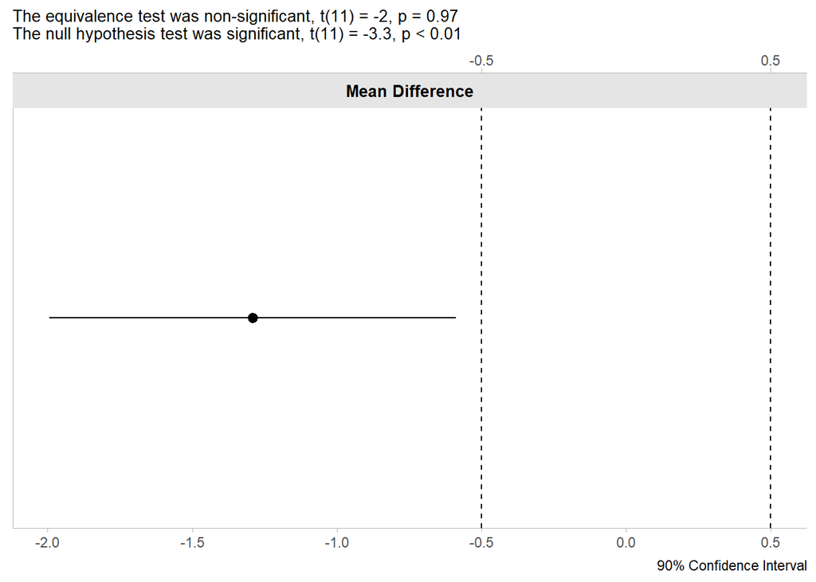

```r
plot(EQ1_SP, "simple", estimates = "raw")
```

#### Second Threshold (RCP vs. BP2)

##### Assumptions - heart rate

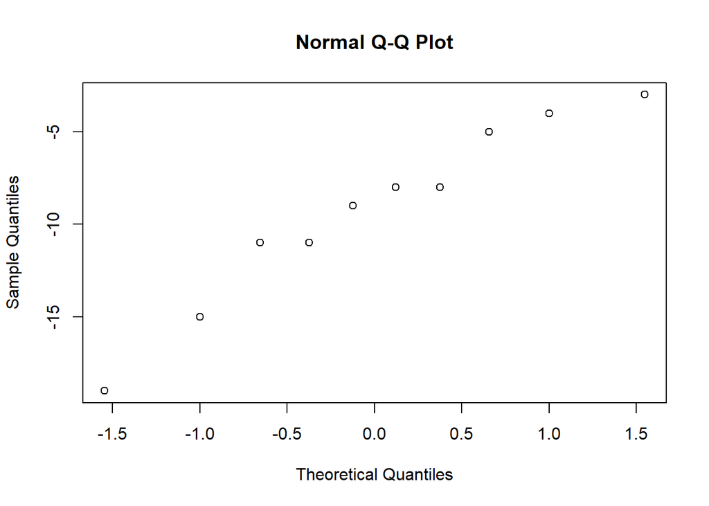

```r
# the steps are the same as above

diff_HR2 <- Study_data$RCP_HR - Study_data$BP2_HR

qqnorm(diff_HR2)
```

```r
shapiro.test(diff_HR2)
```

```
    Shapiro-Wilk normality test

data:  diff_HR2
W = 0.94569, p-value = 0.6178
```

The assumption of normality of the differences is not violated for heart rate.

##### TOST heart rate second threshold

```r
EQ2_HR <- t_TOST(
  x = Study_data$RCP_HR,
  y = Study_data$BP2_HR,
  hypothesis = "EQU",
  paired = T,
  #var.equal = T,
  eqb = 5,
  alpha = 0.05
)

EQ2_HR
```

```
Paired t-test

The equivalence test was non-significant, t(9) = -2.7, p = 0.99
The null hypothesis test was significant, t(9) = -5.92, p < 0.01
NHST: reject null significance hypothesis that the effect is equal to zero
TOST: don't reject null equivalence hypothesis

TOST Results
                t df p.value
t-test     -5.920  9 < 0.001
TOST Lower -2.737  9   0.989
TOST Upper -9.103  9 < 0.001

Effect Sizes
              Estimate     SE                C.I. Conf. Level
Raw             -9.300 1.5709 [-12.1797, -6.4203]         0.9
Hedges's g(z)   -1.711 0.5488  [-2.4909, -0.8751]         0.9
Note: SMD confidence intervals are an approximation. See vignette("SMD_calcs").
```

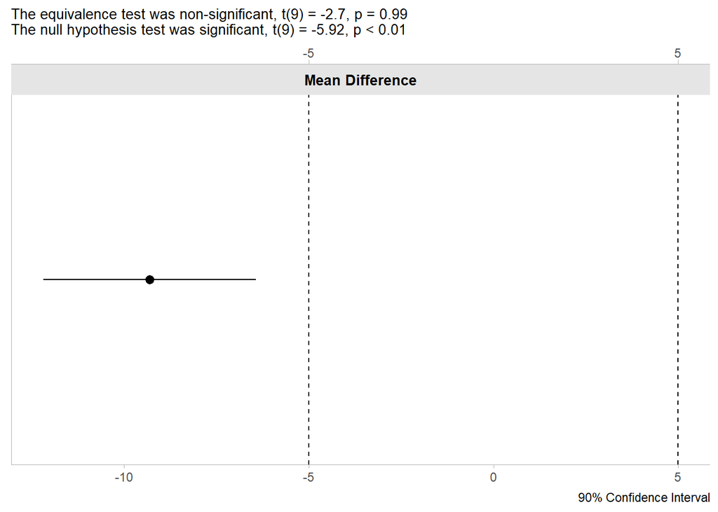

```r
plot(EQ2_HR, "simple", estimates = "raw")
```

##### Assumptions - speed

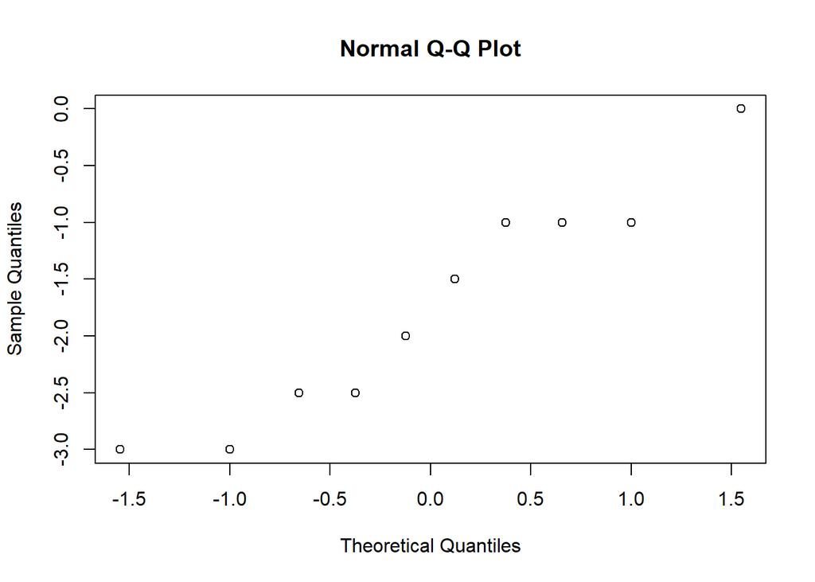

```r
diff_SP2 <- Study_data$RCP_speed - Study_data$BP2_speed

qqnorm(diff_SP2)
```

```r
shapiro.test(diff_SP2)
```

```
    Shapiro-Wilk normality test

data:  diff_SP2
W = 0.92472, p-value = 0.398
```

The assumption of normality of the differences is not violated for speed.

##### TOST speed second threshold

```r
EQ2_SP <- t_TOST(
  x = Study_data$RCP_speed,
  y = Study_data$BP2_speed,
  hypothesis = "EQU",
  paired = T,
  #var.equal = T,
  eqb = 0.5,
  alpha = 0.05
)

EQ2_SP
```

```
Paired t-test

The equivalence test was non-significant, t(9) = -3.9, p = 1
The null hypothesis test was significant, t(9) = -5.5, p < 0.01
NHST: reject null significance hypothesis that the effect is equal to zero
TOST: don't reject null equivalence hypothesis

TOST Results
                t df p.value
t-test     -5.496  9 < 0.001
TOST Lower -3.926  9   0.998
TOST Upper -7.066  9 < 0.001

Effect Sizes
              Estimate     SE               C.I. Conf. Level
Raw             -1.750 0.3184 [-2.3337, -1.1663]         0.9
Hedges's g(z)   -1.588 0.5228  [-2.332, -0.7909]         0.9
Note: SMD confidence intervals are an approximation. See vignette("SMD_calcs").
```

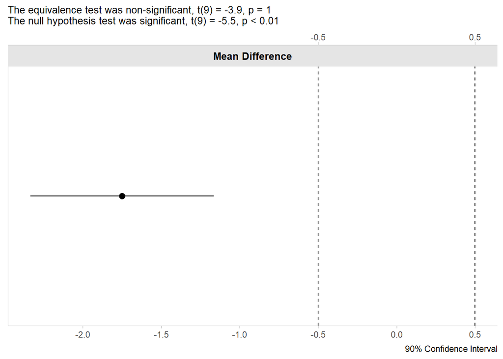

```r
plot(EQ2_SP, "simple", estimates = "raw")
```

### Power Analysis/Sample Size Estimation

Initially we set out to perform a sensitivity analysis to calculate the statistical power we achieved with our sample. However, as the mean differences are outside our pre-defined equivalence range, we cannot calculate our power (it is 0).

What we can do instead is to calculate the sample size needed to achieve 80% power with an $\alpha$ of 0.05, our pre-defined equivalence bounds *if a breakpoint estimation method is used that has a true mean difference of 0 compared to the ventilatory threshold*, and the standard deviation of the difference is reasonably well estimated by the standard deviation of our sample.

```r
# sample size calculation for true zero difference
power_EQ1_HR <- power_t_TOST(
  alpha = 0.05,
  power = 0.80,
  delta = 0,
  sd = EQ1_HR$effsize$SE[[1]]*sqrt(EQ1_HR$smd$ntilde),
  eqb = 5,
  type = "paired"
)

power_EQ2_HR <- power_t_TOST(
  alpha = 0.05,
  power = 0.80,
  delta = 0,
  sd = EQ2_HR$effsize$SE[[1]]*sqrt(EQ2_HR$smd$ntilde),
  eqb = 5,
  type = "paired"
)

power_EQ1_SP <- power_t_TOST(
  alpha = 0.05,
  power = 0.80,
  delta = 0,
  sd = EQ1_SP$effsize$SE[[1]]*sqrt(EQ1_SP$smd$ntilde),
  eqb = 0.5,
  type = "paired"
)

power_EQ2_SP <- power_t_TOST(
  alpha = 0.05,
  power = 0.80,
  delta = 0,
  sd = EQ2_SP$effsize$SE[[1]]*sqrt(EQ2_SP$smd$ntilde),
  eqb = 0.5,
  type = "paired"
)

# sample size calculation for population difference of 2 bpm or 0.2 km/h
power_EQ1_HR_2 <- power_t_TOST(
  alpha = 0.05,
  power = 0.80,
  delta = 2,
  sd = EQ1_HR$effsize$SE[[1]]*sqrt(EQ1_HR$smd$ntilde),
  eqb = 5,
  type = "paired"
)

power_EQ2_HR_2 <- power_t_TOST(
  alpha = 0.05,
  power = 0.80,
  delta = 2,
  sd = EQ2_HR$effsize$SE[[1]]*sqrt(EQ2_HR$smd$ntilde),
  eqb = 5,
  type = "paired"
)

power_EQ1_SP_2 <- power_t_TOST(
  alpha = 0.05,
  power = 0.80,
  delta = 0.2,
  sd = EQ1_SP$effsize$SE[[1]]*sqrt(EQ1_SP$smd$ntilde),
  eqb = 0.5,
  type = "paired"
)

power_EQ2_SP_2 <- power_t_TOST(
  alpha = 0.05,
  power = 0.80,
  delta = 0.2,
  sd = EQ2_SP$effsize$SE[[1]]*sqrt(EQ2_SP$smd$ntilde),
  eqb = 0.5,
  type = "paired"
)


# create an overview table
# this is a bit of a mess, but it works
samplsize_overview <- data.frame(
  c("BP1-GET HR","BP2-RCP HR", "BP1-GET Speed", "BP2-RCP Speed"),
  c(
    round(EQ1_HR$effsize$SE[[1]]*sqrt(EQ1_HR$smd$ntilde),2),
    round(EQ2_HR$effsize$SE[[1]]*sqrt(EQ2_HR$smd$ntilde),2),
    round(EQ1_SP$effsize$SE[[1]]*sqrt(EQ1_SP$smd$ntilde),2),
    round(EQ2_SP$effsize$SE[[1]]*sqrt(EQ2_SP$smd$ntilde),2)),
  c(
    round(power_EQ1_HR$n,0),
    round(power_EQ2_HR$n,0),
    round(power_EQ1_SP$n,0),
    round(power_EQ2_SP$n,0)
  ),
  c(
    round(power_EQ1_HR_2$n,0),
    round(power_EQ2_HR_2$n,0),
    round(power_EQ1_SP_2$n,0),
    round(power_EQ2_SP_2$n,0)
  )
)

samplsize_overview %>%
  kbl(
    col.names = c("Comparison", "Sample SD of the difference", "n for 0 difference", "n for small difference")) %>%
  kable_styling(full_width = FALSE)
```

| Comparison | Sample SD of the difference | n for 0 difference | n for small difference |
| --- | --- | --- | --- |
| BP1-GET HR | 11.74 | 49 | 96 |
| BP2-RCP HR | 4.97 | 10 | 18 |
| BP1-GET Speed | 1.36 | 64 | 128 |
| BP2-RCP Speed | 1.01 | 36 | 71 |

Based on these sample size calculations, we argue that future studies need at least 71 participants to test equivalence of BP2 with RCP an at least 128 participants to test equivalence of BP1 with GET to achieve 80% power *if the new method has the same standard deviation of differences*. If a future method for breakpoint estimation shows less variability (lower standard deviation of differences), lower sample sizes may suffice.

However, **we recommend future studies to specify their expected true difference in advance based on the existing literature.** It is unlikely that the differences is 0, thus resorting to the estimated sample sizes for a true difference of 0 may be perceived as bad practice. As seen in the above table, the required sample sizes are much lower when assuming a true difference of 0, compared to a small difference. This will lead to under-powered studies not able to severely test the hypothesis of equivalence between threshold detection methods.

## Summary

The reliability coefficients are the following:

```r
n_icc <- c(icc_Thd1_HR$n.id,
           icc_Thd1_speed$n.id,
           icc_Thd2_HR$n.id,
           icc_Thd2_speed$n.id)

icc_results <- icc_results %>%
  mutate(
    "ICC" = round(icc,2),
    "n" = n_icc,
    "95% CI" = paste0("[",round(lower.ci,2)," , ",round(upper.ci,2),"]")
    ) %>%
  select(Method, n, ICC, `95% CI`)

kbl(icc_results, digits = 3) %>%
  kable_styling(full_width = FALSE)
```

| Method | n | ICC | 95% CI |
| --- | --- | --- | --- |
| Threshold 1 - HR | 12 | 0.64 | [0.16 , 0.86] |
| Threshold 1 - Speed | 12 | 0.27 | [-0.09 , 0.62] |
| Threshold 2 - HR | 10 | 0.69 | [-0.03 , 0.91] |
| Threshold 2 - Speed | 10 | 0.18 | [-0.08 , 0.53] |

The four equivalence tests are summarized in the following table:

```r
options(scipen = 4)

# create the summary data frame
# not the cleanest code but rather manually defining
# all values
summary <- data.frame(
  a = c("BP1-GET HR (bpm)","BP1-GET Speed (km/h)", "BP2-RCP HR (bpm)", "BP2-RCP Speed (km/h)"), # comparison
  b = c(EQ1_HR$TOST[1,4], EQ1_SP$TOST[1,4], EQ2_HR$TOST[1,4],EQ2_SP$TOST[1,4]), # NHST
  c = c(EQ1_HR$TOST[2,4], EQ1_SP$TOST[2,4], EQ2_HR$TOST[2,4],EQ2_SP$TOST[2,4]), # Equalence test
  d = c(EQ1_HR$effsize[1,1], EQ1_SP$effsize[1,1], EQ2_HR$effsize[1,1],EQ2_SP$effsize[1,1]), # effect size
  e = c(EQ1_HR$effsize[1,3], EQ1_SP$effsize[1,3], EQ2_HR$effsize[1,3],EQ2_SP$effsize[1,3]), # CI_lower
  f = c(EQ1_HR$effsize[1,4], EQ1_SP$effsize[1,4], EQ2_HR$effsize[1,4],EQ2_SP$effsize[1,4]) # CI_upper
)

# and print as a kable
summary %>%
  mutate(
    across(c(b,c), ~ round(.x,4)),
    across(c(d,e,f), ~ round(.x,2))
  ) %>%
  kbl(col.names = c(
    "Comparison", "p NHST", "p equivalence test", "difference", "lower CI", "upper CI"
  )) %>%
  kable_styling()
```

| Comparison | p NHST | p equivalence test | difference | lower CI | upper CI |
| --- | --- | --- | --- | --- | --- |
| BP1-GET HR (bpm) | 0.0138 | 0.9126 | -9.92 | -16.00 | -3.83 |
| BP1-GET Speed (km/h) | 0.0071 | 0.9659 | -1.29 | -1.99 | -0.59 |
| BP2-RCP HR (bpm) | 0.0002 | 0.9885 | -9.30 | -12.18 | -6.42 |
| BP2-RCP Speed (km/h) | 0.0004 | 0.9983 | -1.75 | -2.33 | -1.17 |

Based on our previous stated hypotheses, we conclude:

**Hypothesis BP1-GET**

The SmO<sub>2</sub> BP1 is not only not equivalent to GET, but also statistically different.

**Hypothesis BP2-RCP**

The SmO<sub>2</sub> BP2 is not only not equivalent to RCP, but also statistically different.

This is visualized by plotting the mean differences and their 90% CIs (with or without individual data):

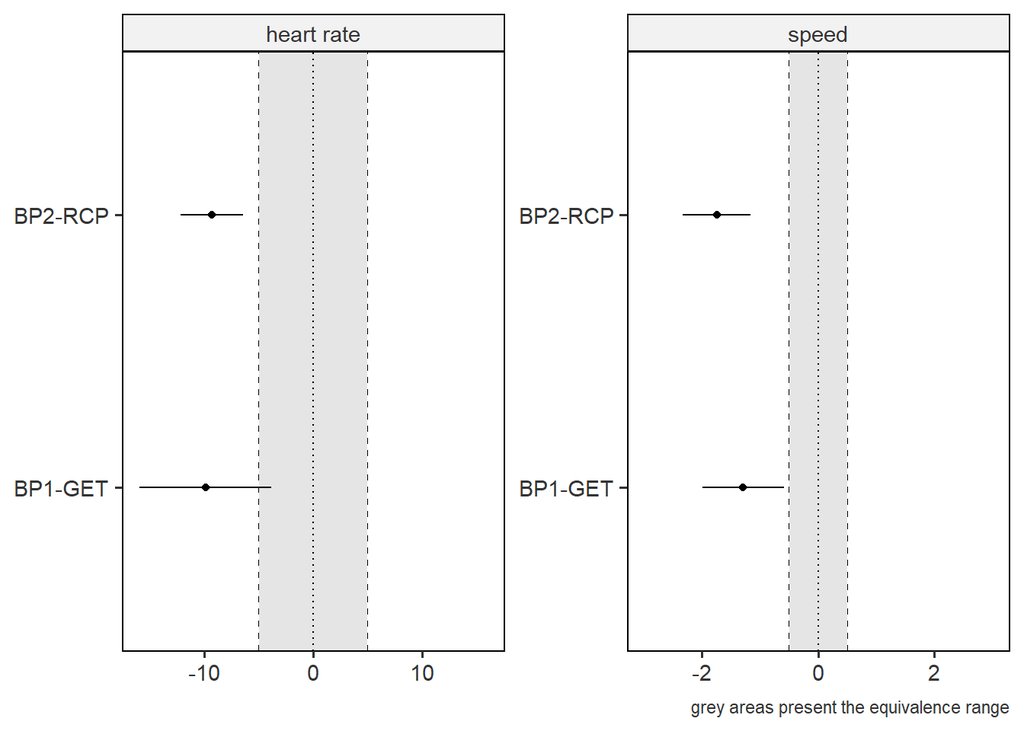

```r
# combine some data
summary_data <- rbind(
  EQ1_HR$eff[1,],
  EQ1_SP$eff[1,],
  EQ2_HR$eff[1,],
  EQ2_SP$eff[1,]
)

# data for vlines
vlines <- data.frame(
  level = c("heart rate","heart rate","speed","speed"),
  vline_pos = c(-5, 5, -0.5, 0.5)
)

# create backgroud shading
shaded_df <- data.frame(
  level = c("heart rate", "speed"),
  xmin = c(-5,-0.5),
  xmax = c(5,0.5),
  ymin = -Inf,
  ymax = Inf
)

# x axis limits
xlimits <- data.frame(
  level = c("heart rate", "speed"),
  x_min = c(-16, -3),
  x_max = c(16, 3)
) %>%
  pivot_longer(cols = c(x_min, x_max),
               names_to = "limit_type",
               values_to = "x")

# create plots for standard mean with 95% CI presentation
summary_data %>%
  mutate(
    level = c("heart rate","speed","heart rate","speed"),
    test = c("BP1-GET","BP1-GET", "BP2-RCP", "BP2-RCP")
  ) %>%
  ggplot(aes(estimate, test)) +
  geom_vline(data = vlines, aes(xintercept = vline_pos), linetype = 2) +
  geom_rect(data= shaded_df, aes (xmin = xmin, xmax = xmax, ymin = ymin, ymax = ymax), fill = "grey90", inherit.aes = FALSE) +
  geom_vline(xintercept = 0, linetype = 3) +
  geom_blank(data = xlimits, aes(x = x), inherit.aes = FALSE) +
  geom_point() +
  geom_linerange(aes(xmin = lower.ci, xmax = upper.ci)) +
  facet_wrap(~level, scales = "free") +
  labs(
    x = NULL,
    y = NULL,
    caption = "grey areas present the equivalence range"
  )
```

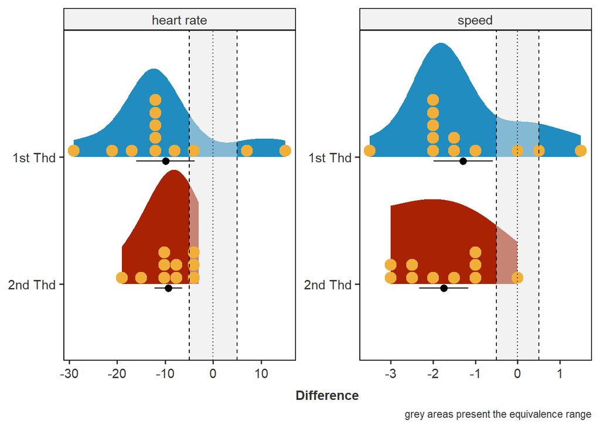

```r
# data for vlines
vlines <- data.frame(
  Measure = c("heart rate","heart rate","speed","speed"),
  vline_pos = c(-5, 5, -0.5, 0.5)
)

# create backgroud shading
shaded_df <- data.frame(
  Measure = c("heart rate", "speed"),
  xmin = c(-5,-0.5),
  xmax = c(5,0.5),
  ymin = -Inf,
  ymax = Inf
)

# x axis limits
xlimits <- data.frame(
  Measure = c("heart rate", "speed"),
  x_min = c(-16, -3),
  x_max = c(16, 3)
) %>%
  pivot_longer(cols = c(x_min, x_max),
               names_to = "limit_type",
               values_to = "x")

# create plots with density and individual data points
Study_data %>%
  mutate(diffHR1 = GET_HR - BP1_HR,
         diffSP1 = GET_speed - BP1_speed,
         diffHR2 = RCP_HR - BP2_HR,
         diffSP2 = RCP_speed - BP2_speed) %>%
  pivot_longer(
    cols = starts_with("diff"),
    names_to = "Comparison",
    values_to = "Difference",
    names_prefix = "diff"
  ) %>%
  mutate(Measure = ifelse(str_starts(Comparison, "SP"),"speed", "heart rate"),
         Threshold = ifelse(str_ends(Comparison, "1"),"1st Thd","2nd Thd"),
         Threshold = factor (Threshold, levels = c("2nd Thd","1st Thd"))) %>%
  ggplot(aes(Difference, Threshold, fill = Threshold)) +
  stat_slab(normalize = "panels", adjust = 1.5) +
  geom_rect(data= shaded_df,
            aes (xmin = xmin, xmax = xmax, ymin = ymin, ymax = ymax),
            fill = "grey90", alpha = 0.5, inherit.aes = FALSE) +
  stat_dots(color = clrs[3], fill = clrs[3], scale = 0.5) +
  geom_vline(data = vlines, aes(xintercept = vline_pos), linetype = 2) +
  geom_vline(xintercept = 0, linetype = 3) +
  stat_summary(fun = mean, geom = "point", color = "black", size = 2, position = position_nudge(y = -0.03)) +
  stat_summary(fun.data = mean_cl_normal, fun.args = list(conf.int = 0.90),
               geom = "pointrange", color = "black", position = position_nudge(y = -0.03)) +
  facet_wrap(~Measure, scales = "free") +
  labs(
    y = NULL,
    caption = "grey areas present the equivalence range"
  ) +
  scale_color_manual(values = c(clrs[1:2])) +
  scale_fill_manual(values = c(clrs[1:2])) +
  theme(
    legend.position = "none"
    )
```

## Content for the manuscript

### Figure 1

```r
#load the raw data for participants ID_03 and ID_06
ID3_data <- read_xlsx("data/input data/ID_03.xlsx")
ID6_data <- read_xlsx("data/input data/ID_06.xlsx")

pID3 <- ID3_data %>%
  ggplot(aes(Time,SmO2_right)) +
  geom_point(size = 2) +
  # now add vertical lines for the BPs and annotate them
  geom_vline(xintercept = as.numeric(Study_data %>% filter(ID == 3) %>% select(BP1_time,BP2_time)),
             linetype = 2, linewidth = 1,
             color = clrs[1]) +
  annotate("text",
           x = as.numeric(Study_data %>% filter(ID == 3) %>% select(BP1_time,BP2_time))+10,
           y = 100,
           label = c("BP1","BP2"),
           hjust = 0,
           color = clrs[1]) +
  # repeat for VTs
  geom_vline(xintercept = as.numeric(Study_data %>% filter(ID == 3) %>% select(GET_time,RCP_time)),
             linetype = 2, linewidth = 1,
             color = clrs[2]) +
  annotate("text",
           x = as.numeric(Study_data %>% filter(ID == 3) %>% select(GET_time,RCP_time))+10,
           y = 95,
           label = c("GET","RCP"),
           hjust = 0,
           color = clrs[2]) +
  scale_y_continuous(limits = c(0,100), breaks = seq(0,100,20)) +
  scale_x_continuous(limits = c(0,1500), breaks = seq(0,1470,240)) +
  labs(
    x = "Time [s]",
    y = expression(bold(SmO[2]~"[%]")),
    caption = "ID03"
  ) +
  theme(
    axis.title = element_text(family = "Arial", size = 9),
    axis.text = element_text(family = "Arial", size = 9),
    text = element_text(family = "Arial", size = 9)
  )

pID6 <- ID6_data %>%
  ggplot(aes(Time,SmO2_right)) +
  geom_point(size = 2) +
  # now add vertical lines for the BPs and annotate them
  geom_vline(xintercept = as.numeric(Study_data %>% filter(ID == 6) %>% select(BP1_time,BP2_time)),
             linetype = 2, linewidth = 1,
             color = clrs[1]) +
  annotate("text",
           x = as.numeric(Study_data %>% filter(ID == 6) %>% select(BP1_time,BP2_time))+10,
           y = 100,
           label = c("BP1","BP2"),
           hjust = 0,
           color = clrs[1]) +
  # repeat for VTs
  geom_vline(xintercept = as.numeric(Study_data %>% filter(ID == 6) %>% select(GET_time,RCP_time)),
             linetype = 2, linewidth = 1,
             color = clrs[2]) +
  annotate("text",
           x = as.numeric(Study_data %>% filter(ID == 6) %>% select(GET_time,RCP_time))+10,
           y = 95,
           label = c("GET","RCP"),
           hjust = 0,
           color = clrs[2]) +
  scale_y_continuous(limits = c(0,100), breaks = seq(0,100,20)) +
  scale_x_continuous(limits = c(0,1500), breaks = seq(0,1260,240)) +
  labs(
    x = "Time [s]",
    y = expression(bold(SmO[2]~"[%]")),
    caption = "ID06"
  ) +
  theme(
    axis.title = element_text(family = "Arial", size = 9),
    axis.text = element_text(family = "Arial", size = 9),
    text = element_text(family = "Arial", size = 9)
  )

# now combine plots next to each other
Fig1 <- pID3 + pID6 +
  patchwork::plot_annotation(tag_levels = "A")

ggsave("output/results/Fig1.jpeg",
       plot = Fig1,
       device = "jpeg",
       width = 300,
       height = 112.5,
       units = "mm",
       dpi = 1200)

ggsave("output/results/Fig1.eps",
       plot = Fig1,
       device = cairo_ps,
       width = 300,
       height = 112.5,
       units = "mm",
       dpi = 1200)
```

### Figure 2

```r
# create labels to add the ICC to the boxplots
icc_labels_speed <- data.frame(
  Threshold = c("Threshold 1", "Threshold 2"),
  ICC   = c(icc_Thd1_speed$icc[2, 4], icc_Thd2_speed$icc[2, 4]),
  lower = c(icc_Thd1_speed$icc[2, 5], icc_Thd2_speed$icc[2, 5]),
  upper = c(icc_Thd1_speed$icc[2, 6], icc_Thd2_speed$icc[2, 6]),
  n     = c(icc_Thd1_speed$n.id,       icc_Thd2_speed$n.id)
) |>
  mutate(label = paste0(
    "ICC(3,1)[abs] == '",
    round(ICC, 2), " [", round(lower, 2), ", ", round(upper, 2), "] (n = ", n, ")'"
  ))

icc_labels_HR <- data.frame(
  Threshold = c("Threshold 1", "Threshold 2"),
  ICC   = c(icc_Thd1_HR$icc[2, 4], icc_Thd2_HR$icc[2, 4]),
  lower = c(icc_Thd1_HR$icc[2, 5], icc_Thd2_HR$icc[2, 5]),
  upper = c(icc_Thd1_HR$icc[2, 6], icc_Thd2_HR$icc[2, 6]),
  n     = c(icc_Thd1_HR$n.id,       icc_Thd2_HR$n.id)
) |>
  mutate(label = paste0(
    "ICC(3,1)[abs] == '",
    round(ICC, 2), " [", round(lower, 2), ", ", round(upper, 2), "] (n = ", n, ")'"
  ))

Fig2A <- bxplt_data |>
  ggplot(aes(Measure, speed, group = Measure, fill = Method)) +
  geom_boxplot(alpha = .5) +
  geom_point(aes(group = ID), size = 2) +
  geom_line(aes(group = ID), color = "grey40", alpha = 0.7, linewidth = 0.6) +
  geom_text(
    data = icc_labels_speed,
    aes(label = label, x = -Inf, y = Inf),
    hjust = -0.05, vjust = 1.5,
    size = 3, inherit.aes = FALSE,
    parse = TRUE
  ) +
  facet_wrap(~Threshold,
             scales = "free_x") +
  scale_fill_manual(values = c(clrs[1:2])) +
  scale_y_continuous(limits = c(NA,21)) +
  labs(
    x = NULL,
    y = "Speed [km/h]"
  ) +
  theme(
    legend.position = "none",
    axis.title = element_text(family = "Arial", size = 9),
    axis.text = element_text(family = "Arial", size = 9),
    text = element_text(family = "Arial", size = 9)
  )

Fig2B <- bxplt_data |>
  ggplot(aes(Measure, HR, group = Measure, fill = Method)) +
  geom_boxplot(alpha = .5) +
  geom_point(aes(group = ID), size = 2) +
  geom_line(aes(group = ID), color = "grey40", alpha = 0.7, linewidth = 0.6) +
  geom_text(
    data = icc_labels_HR,
    aes(label = label, x = -Inf, y = Inf),
    hjust = -0.05, vjust = 1.5,
    size = 3, inherit.aes = FALSE,
    parse = TRUE
  ) +
  facet_wrap(~Threshold,
             scales = "free_x") +
  scale_fill_manual(values = c(clrs[1:2])) +
  scale_y_continuous(limits = c(NA,210)) +
  labs(
    x = NULL,
    y = "Heart rate [bpm]"
  ) +
  theme(
    legend.position = "none",
    axis.title = element_text(family = "Arial", size = 9),
    axis.text = element_text(family = "Arial", size = 9),
    text = element_text(family = "Arial", size = 9)
  )


# now combine plots next to each other
Fig2 <- Fig2A + Fig2B +
  patchwork::plot_annotation(tag_levels = "A")

ggsave("output/results/Fig2.jpeg",
       plot = Fig2,
       device = "jpeg",
       width = 300,
       height = 112.5,
       units = "mm",
       dpi = 1200)

ggsave("output/results/Fig2.eps",
       plot = Fig2,
       device = cairo_ps,
       width = 300,
       height = 112.5,
       units = "mm",
       dpi = 1200)
```

### Figure 3

```r
########################################################
# for this figure, some advanced formatting is required
########################################################

# create differece data
plot_data <- Study_data %>%
  mutate(diffHR1 = GET_HR - BP1_HR,
         diffSP1 = GET_speed - BP1_speed,
         diffHR2 = RCP_HR - BP2_HR,
         diffSP2 = RCP_speed - BP2_speed) %>%
  pivot_longer(
    cols = starts_with("diff"),
    names_to = "Comparison",
    values_to = "Difference",
    names_prefix = "diff"
  ) %>%
  mutate(Measure = ifelse(str_starts(Comparison, "SP"),"Speed [km/h]", "Heart Rate [bpm]"),
         Threshold = ifelse(str_ends(Comparison, "1"),"1st Thd","2nd Thd"),
         Threshold = factor (Threshold, levels = c("2nd Thd","1st Thd")))

# create functions to draw not all plot boarders
## remove right border
three_sided_border <- function(colour = "black", linewidth = 0.7) {
  structure(
    list(colour = colour, linewidth = linewidth),
    class = c("three_sided_border", "element_blank", "element", "rel")
  )
}

element_grob.three_sided_border <- function(element, x = 0, y = 0, width = 1, height = 1, ...) {
  polylineGrob(
    x = c(x,         x + width,   # bottom
           x,         x,           # left
           x,         x + width),  # top
    y = c(y,         y,            # bottom
           y,         y + height,  # left
           y + height, y + height), # top
    id = c(1, 1, 2, 2, 3, 3),
    default.units = "npc",
    gp = gpar(lwd = element$linewidth * .pt, col = element$colour)
  )
}
## remove left border
three_sided_border_noleft <- function(colour = "black", linewidth = 0.7) {
  structure(
    list(colour = colour, linewidth = linewidth),
    class = c("three_sided_border_noleft", "element_blank", "element", "rel")
  )
}

element_grob.three_sided_border_noleft <- function(element, x = 0, y = 0, width = 1, height = 1, ...) {
  polylineGrob(
    x = c(x,           x + width,    # bottom
           x + width,   x + width,    # right
           x,           x + width),   # top
    y = c(y,           y,             # bottom
           y,           y + height,   # right
           y + height,  y + height),  # top
    id = c(1, 1, 2, 2, 3, 3),
    default.units = "npc",
    gp = gpar(lwd = element$linewidth * .pt, col = element$colour)
  )
}

# data for equivalence lines
vlines <- data.frame(
  Measure = c("Heart Rate [bpm]","Heart Rate [bpm]","Speed [km/h]","Speed [km/h]"),
  vline_pos = c(-5, 5, -0.5, 0.5)
)

# create backgroud shading
shaded_df <- data.frame(
  Measure = c("Heart Rate [bpm]", "Speed [km/h]"),
  xmin = c(-5,-0.5),
  xmax = c(5,0.5),
  ymin = -Inf,
  ymax = Inf
)

# x axis limits
xlimits <- data.frame(
  Measure = c("Heart Rate [bpm]", "Speed [km/h]"),
  x_min = c(-16, -3),
  x_max = c(16, 3)
) %>%
  pivot_longer(cols = c(x_min, x_max),
               names_to = "limit_type",
               values_to = "x")


# now use the bland altman plots as basis for the left side and equivalence plots for right side of the final plots

## Thd1 HR
### bland altman
ba_Thd1_HR <- ba_Thd1_HR +
  geom_hline(yintercept = BA_VT1_HR$loa$bias, linetype = "solid", color = clrs[2]) +
  # geom_hline(yintercept = c(BA_VT1_HR$loa$lower_loa, BA_VT1_HR$loa$upper_loa), linetype = "dashed", color = clrs[1]) +
  geom_rect(data = shaded_df %>% filter(Measure == "Heart Rate [bpm]"), # filter for relevant column
            aes(ymin = xmin, ymax = xmax, xmin = ymin, xmax = ymax),
            fill = "grey90", alpha = 0.5, inherit.aes = FALSE) +
  # geom_hline(data = vlines %>% filter(Measure == "Heart Rate [bpm]"), # filter for relevant column
  #            aes(yintercept = vline_pos), linetype = 2) +
  geom_hline(yintercept = 0, linetype = 1) +
  geom_point(size = 2) +
  scale_y_continuous(limits = c(-35,15)) +
  labs(
    x = "Mean heart rate [bpm]",
    y = "Difference in speed [GET minus BP1]"
  ) +
  theme(
    plot.margin = margin(t = 5, r = 0, b = 5, l = 5),
    panel.border = three_sided_border(colour = "black", linewidth = 0.7)
  )

### equivalence
eq_Thd1_HR <- plot_data %>%
  filter(Threshold == "1st Thd" & Measure == "Heart Rate [bpm]") %>%
  ggplot(aes(Threshold, Difference, fill = Threshold)) +
  stat_slab(normalize = "panels", adjust = 1.5, alpha = 0.5, fill = clrs[3]) +
  geom_rect(data = shaded_df %>% filter(Measure == "Heart Rate [bpm]"), # filter for relevant column
            aes(ymin = xmin, ymax = xmax, xmin = ymin, xmax = ymax),
            fill = "grey90", alpha = 0.5, inherit.aes = FALSE) +
  # geom_hline(data = vlines %>% filter(Measure == "Heart Rate [bpm]"), # filter for relevant column
  #            aes(yintercept = vline_pos), linetype = 2) +
  geom_hline(yintercept = 0, linetype = 1) +
  stat_summary(fun = mean, geom = "point", color = "black", size = 3,
               position = position_nudge(x = -0.1)) +
  stat_summary(fun.data = mean_cl_normal, fun.args = list(conf.int = 0.90),
               geom = "errorbar", color = "black",
               position = position_nudge(x = -0.1), linewidth = 1, width = 0.1) +
  labs(
    x = NULL,
    y = NULL
  ) +
  scale_y_continuous(limits = c(-35,15)) +
  theme(
  legend.position = "none",
  axis.title = element_blank(),
  axis.text = element_blank(),
  axis.ticks = element_blank(),
  panel.border = three_sided_border_noleft(colour = "black", linewidth = 0.7),
  plot.margin = margin(t = 5, r = 5, b = 5, l = 0)
)

# combine plots with 80/20 width distribution
p_Thd1_HR <- ba_Thd1_HR + eq_Thd1_HR + plot_layout(widths = c(4, 1))

## Thd1 Speed
### bland altman
ba_Thd1_speed <- ba_Thd1_speed +
  geom_hline(yintercept = BA_VT1_speed$loa$bias, linetype = "solid", color = clrs[2]) +
  # geom_hline(yintercept = c(BA_VT1_speed$loa$lower_loa, BA_VT1_speed$loa$upper_loa), linetype = "dashed", color = clrs[1]) +
  geom_rect(data = shaded_df %>% filter(Measure == "Speed [km/h]"), # filter for relevant column
            aes(ymin = xmin, ymax = xmax, xmin = ymin, xmax = ymax),
            fill = "grey90", alpha = 0.5, inherit.aes = FALSE) +
  # geom_hline(data = vlines %>% filter(Measure == "Speed [km/h]"), # filter for relevant column
  #            aes(yintercept = vline_pos), linetype = 2) +
  geom_hline(yintercept = 0, linetype = 1) +
  geom_point(size = 2) +
  scale_y_continuous(limits = c(-4,2)) +
  labs(
    x = "Mean speed [km/h]",
    y = "Difference in speed [GET minus BP1]"
  ) +
  theme(
    plot.margin = margin(t = 5, r = 0, b = 5, l = 5),
    panel.border = three_sided_border(colour = "black", linewidth = 0.7)
  )
```

```r
### equivalence
eq_Thd1_speed <- plot_data %>%
  filter(Threshold == "1st Thd" & Measure == "Speed [km/h]") %>%
  ggplot(aes(Threshold, Difference, fill = Threshold)) +
  stat_slab(normalize = "panels", adjust = 1.5, alpha = 0.5, fill = clrs[3]) +
  geom_rect(data = shaded_df %>% filter(Measure == "Speed [km/h]"), # filter for relevant column
            aes(ymin = xmin, ymax = xmax, xmin = ymin, xmax = ymax),
            fill = "grey90", alpha = 0.5, inherit.aes = FALSE) +
  # geom_hline(data = vlines %>% filter(Measure == "Speed [km/h]"), # filter for relevant column
  #            aes(yintercept = vline_pos), linetype = 2) +
  geom_hline(yintercept = 0, linetype = 1) +
  stat_summary(fun = mean, geom = "point", color = "black", size = 3,
               position = position_nudge(x = -0.1)) +
  stat_summary(fun.data = mean_cl_normal, fun.args = list(conf.int = 0.90),
               geom = "errorbar", color = "black",
               position = position_nudge(x = -0.1), linewidth = 1, width = 0.1) +
  labs(
    x = NULL,
    y = NULL
  ) +
  scale_y_continuous(limits = c(-4, 2)) +
theme(
  legend.position = "none",
  axis.title = element_blank(),
  axis.text = element_blank(),
  axis.ticks = element_blank(),
  panel.border = three_sided_border_noleft(colour = "black", linewidth = 0.7),
  plot.margin = margin(t = 5, r = 5, b = 5, l = 0)
)

# combine plots with 80/20 width distribution
p_Thd1_speed <- ba_Thd1_speed + eq_Thd1_speed + plot_layout(widths = c(4, 1))

## Thd2 HR
### bland altman
ba_Thd2_HR <- ba_Thd2_HR +
  geom_hline(yintercept = BA_VT2_HR$loa$bias, linetype = "solid", color = clrs[2]) +
  # geom_hline(yintercept = c(BA_VT2_HR$loa$lower_loa, BA_VT2_HR$loa$upper_loa), linetype = "dashed", color = clrs[1]) +
  geom_rect(data = shaded_df %>% filter(Measure == "Heart Rate [bpm]"), # filter for relevant column
            aes(ymin = xmin, ymax = xmax, xmin = ymin, xmax = ymax),
            fill = "grey90", alpha = 0.5, inherit.aes = FALSE) +
  # geom_hline(data = vlines %>% filter(Measure == "Heart Rate [bpm]"), # filter for relevant column
  #            aes(yintercept = vline_pos), linetype = 2) +
  geom_hline(yintercept = 0, linetype = 1) +
  geom_point(size = 2) +
  scale_y_continuous(limits = c(-35,15)) +
  labs(
    x = "Mean heart rate [bpm]",
    y = "Difference in speed [RCP minus BP2]"
  ) +
  theme(
    plot.margin = margin(t = 5, r = 0, b = 5, l = 5),
    panel.border = three_sided_border(colour = "black", linewidth = 0.7)
  )

### equivalence
eq_Thd2_HR <- plot_data %>%
  filter(Threshold == "2nd Thd" & Measure == "Heart Rate [bpm]") %>%
  ggplot(aes(Threshold, Difference, fill = Threshold)) +
  stat_slab(normalize = "panels", adjust = 1.5, alpha = 0.5, fill = clrs[3]) +
  geom_rect(data = shaded_df %>% filter(Measure == "Heart Rate [bpm]"), # filter for relevant column
            aes(ymin = xmin, ymax = xmax, xmin = ymin, xmax = ymax),
            fill = "grey90", alpha = 0.5, inherit.aes = FALSE) +
  # geom_hline(data = vlines %>% filter(Measure == "Heart Rate [bpm]"), # filter for relevant column
  #            aes(yintercept = vline_pos), linetype = 2) +
  geom_hline(yintercept = 0, linetype = 1) +
  stat_summary(fun = mean, geom = "point", color = "black", size = 3,
               position = position_nudge(x = -0.1)) +
  stat_summary(fun.data = mean_cl_normal, fun.args = list(conf.int = 0.90),
               geom = "errorbar", color = "black",
               position = position_nudge(x = -0.1), linewidth = 1, width = 0.1) +
  labs(
    x = NULL,
    y = NULL
  ) +
  scale_y_continuous(limits = c(-35,15)) +
theme(
  legend.position = "none",
  axis.title = element_blank(),
  axis.text = element_blank(),
  axis.ticks = element_blank(),
  panel.border = three_sided_border_noleft(colour = "black", linewidth = 0.7),
  plot.margin = margin(t = 5, r = 5, b = 5, l = 0)
)

# combine plots with 80/20 width distribution
p_Thd2_HR <- ba_Thd2_HR + eq_Thd2_HR + plot_layout(widths = c(4, 1))

## Thd2 Speed
### bland altman
ba_Thd2_speed <- ba_Thd2_speed +
  geom_hline(yintercept = BA_VT2_speed$loa$bias, linetype = "solid", color = clrs[2]) +
  # geom_hline(yintercept = c(BA_VT2_speed$loa$lower_loa, BA_VT2_speed$loa$upper_loa), linetype = "dashed", color = clrs[1]) +
  geom_rect(data = shaded_df %>% filter(Measure == "Speed [km/h]"), # filter for relevant column
            aes(ymin = xmin, ymax = xmax, xmin = ymin, xmax = ymax),
            fill = "grey90", alpha = 0.5, inherit.aes = FALSE) +
  # geom_hline(data = vlines %>% filter(Measure == "Speed [km/h]"), # filter for relevant column
  #            aes(yintercept = vline_pos), linetype = 2) +
  geom_hline(yintercept = 0, linetype = 1) +
  geom_point(size = 2) +
  scale_y_continuous(limits = c(-4,2)) +
  labs(
    x = "Mean speed [km/h]",
    y = "Difference in speed [RCP minus BP2]"
  ) +
  theme(
    plot.margin = margin(t = 5, r = 0, b = 5, l = 5),
    panel.border = three_sided_border(colour = "black", linewidth = 0.7)
  )

### equivalence
eq_Thd2_speed <- plot_data %>%
  filter(Threshold == "2nd Thd" & Measure == "Speed [km/h]") %>%
  ggplot(aes(Threshold, Difference, fill = Threshold)) +
  stat_slab(normalize = "panels", adjust = 1.5, alpha = 0.5, fill = clrs[3]) +
  geom_rect(data = shaded_df %>% filter(Measure == "Speed [km/h]"), # filter for relevant column
            aes(ymin = xmin, ymax = xmax, xmin = ymin, xmax = ymax),
            fill = "grey90", alpha = 0.5, inherit.aes = FALSE) +
  # geom_hline(data = vlines %>% filter(Measure == "Speed [km/h]"), # filter for relevant column
  #            aes(yintercept = vline_pos), linetype = 2) +
  geom_hline(yintercept = 0, linetype = 1) +
  stat_summary(fun = mean, geom = "point", color = "black", size = 3,
               position = position_nudge(x = -0.1)) +
  stat_summary(fun.data = mean_cl_normal, fun.args = list(conf.int = 0.90),
               geom = "errorbar", color = "black",
               position = position_nudge(x = -0.1), linewidth = 1, width = 0.1) +
  labs(
    x = NULL,
    y = NULL
  ) +
  scale_y_continuous(limits = c(-4,2)) +
theme(
  legend.position = "none",
  axis.title = element_blank(),
  axis.text = element_blank(),
  axis.ticks = element_blank(),
  panel.border = three_sided_border_noleft(colour = "black", linewidth = 0.7),
  plot.margin = margin(t = 5, r = 5, b = 5, l = 0)
)
```

```r
# combine plots with 80/20 width distribution
p_Thd2_speed <- ba_Thd2_speed + eq_Thd2_speed + plot_layout(widths = c(4, 1))


Fig3 <- (wrap_elements(p_Thd1_speed) | wrap_elements(p_Thd2_speed)) /
        (wrap_elements(p_Thd1_HR) | wrap_elements(p_Thd2_HR)) +
  plot_annotation(tag_levels = "A")

ggsave("output/results/Fig3.jpeg",
       plot = Fig3,
       device = "jpeg",
       width = 300,
       height = 225,
       units = "mm",
       dpi = 1200)

ggsave("output/results/Fig3.eps",
       plot = Fig3,
       device = cairo_ps,
       width = 150,
       height = 112.5,
       units = "mm",
       dpi = 1200)
```

### Table 1

```r
Tbl1 <- Study_data %>%
  select(Age, Height, Weight, ATT_left, ATT_right, Test_duration, v_peak, MAS, absVO2max, VO2max) %>%
  mutate(BMI = Weight / (Height/100)^2,
         Test_duration = Test_duration/60) %>%
    tbl_summary(
    type = ~ "continuous",
    statistic = all_continuous() ~ "{mean} \u00B1 {sd} [{min} - {max}]",
    missing_text = "missing",
    digits = list(
      c(Age, Height, Weight, ATT_left, ATT_right, Test_duration, v_peak, MAS, VO2max, BMI) ~ 1,
      c(absVO2max) ~ 0
    )
  ) %>%
  as_gt() %>%
  tab_options(table.font.size = px(12)) %>%
  opt_table_font(font = list(gt::google_font("Arial")))

# and export in various formats

# html
gtsave(Tbl1, "output/results/Tbl1.html")

# png
gtsave(Tbl1, "output/results/Tbl1.png")

# latex
gtsave(Tbl1, "output/results/Tbl1.tex")

# word # commented out as it throws an error (but works)
# gtsave(Tbl1, "output/results/Tbl1.docx")
```

## References

Cerezuela-Espejo, V., Courel-Ibáñez, J., Morán-Navarro, R., Martínez-Cava, A., & Pallarés, J. G. (2018). The relationship between lactate and ventilatory thresholds in runners: Validity and reliability of exercise test performance parameters. *Frontiers in Physiology*, *9*. https://doi.org/10.3389/fphys.2018.01320

Dickhuth, H.-H., Yin, L., Niess, A., Röcker, K., Mayer, F., Heitkamp, H.-C., & Horstmann, T. (1999). Ventilatory, lactate-derived and catecholamine thresholds during incremental treadmill running: Relationship and reproducibility. *International Journal of Sports Medicine*, *20*(02), 122–127. https://doi.org/10.1055/s-2007-971105

Ditroilo, M., Mesquida, C., Abt, G., & Lakens, D. (2025). Exploratory research in sport and exercise science: Perceptions, challenges, and recommendations. *Journal of Sports Sciences*, 1–13. https://doi.org/10.1080/02640414.2025.2486871

Dörr, C. (2010). *Untersuchung der validität verschiedener laktatschwellenkonzepte an ausdauersportlern* [PhD thesis]. http://geb.uni-giessen.de/geb/volltexte/2010/7859/

Lakens, D. (2017). Equivalence Tests: A Practical Primer for t Tests, Correlations, and Meta-Analyses. *Social Psychological and Personality Science*. https://doi.org/10.1177/1948550617697177

Mesquida, C., Warne, J., & Lakens, D. (n.d.). *What is your hypothesis? : On the importance of knowing your hypothesis before conducting a hypothesis test*. https://doi.org/10.51224/SRXIV.577

Weston, S. B., & Gabbett, T. J. (2001). Reproducibility of ventilation of thresholds in trained cyclists during ramp cycle exercise. *Journal of Science and Medicine in Sport*, *4*(3), 357–366. https://doi.org/10.1016/S1440-2440(01)80044-X

Yogev, A., Arnold, J., Nelson, H., Clarke, D. C., Guenette, J. A., Sporer, B. C., & Koehle, M. S. (2023). Comparing the reliability of muscle oxygen saturation with common performance and physiological markers across cycling exercise intensity. *Frontiers in Sports and Active Living*, *5*. https://doi.org/https://doi.org/10.3389/fspor.2023.1143393